# Study on the degree of transparency of the local public administration in Romania in a pandemic context

Mari-Isabella Stan

1  
stanisabella@yahoo.com

Cristian Opariuc-Dan

1

Tănase Tasențe

1

Abstract

```r
  # Seed for random number generation
  set.seed(42)
  knitr::opts_chunk$set(cache.extra = knitr::rand_seed)
```

# Introduction

Decision-making transparency in public administration has become an increasingly important concept in the current context, as it is visible that politicians are distancing themselves from citizens when it comes to making decisions for the benefit of the community. Thus, both transparency of government and free access to public information are very important items on the public agenda as citizens’ trust in public institutions has declined. (Radu (2019)).

Privind fenomenul dintr-o alta perspectiva, Chen and Chang (2019) afirma ca o guvernare mai transparenta este direct proportionala cu reducerea coruptiei si contribuie la cresterea increderii cetatenilor in institutiile publice. Astfel, transparenta administrativa a devenit parte integranta din strategiile de guvernare deschisa, care includ nu doar informatiile de interes public de pe website-urile proprii, cum ar fi: procedurile administrative, hotararile de consiliu local, deciziile administrative, programe si strategii, bugete, declaratiile de avere si de interese, contractele de achizitii etc., ci si diseminarea acestora in social media.

However, according to Radu (2019), this concept of transparency was obviously distorted and manipulative during the communist period in Romania, in the sense that “the decision making process was neither desired nor encouraged, and the decisions were made internally by the communist elite and then communicated on the public agenda”. Even so, the party’s propaganda states that these decisions are representative of the views of the working class, so for the benefit of society, and the contrary views were discouraged and punished.

# Methods

We report how we determined our sample size, all data exclusions (if any), all manipulations, and all measures in the study.

## Participants

## Material

## Procedure

## Data analysis

We used R (Version 4.1.2; R Core Team 2022) and the R-packages *kableExtra* (Version 1.3.4; Zhu 2021), *knitr* (Version 1.39; Xie 2015), *papaja* (Version 0.1.0.9999; Aust and Barth 2020), and *tinylabels* (Version 0.2.3; Barth 2022) for all our analyses.

# Results

# Analiza contingenței în funcție de rangul localității

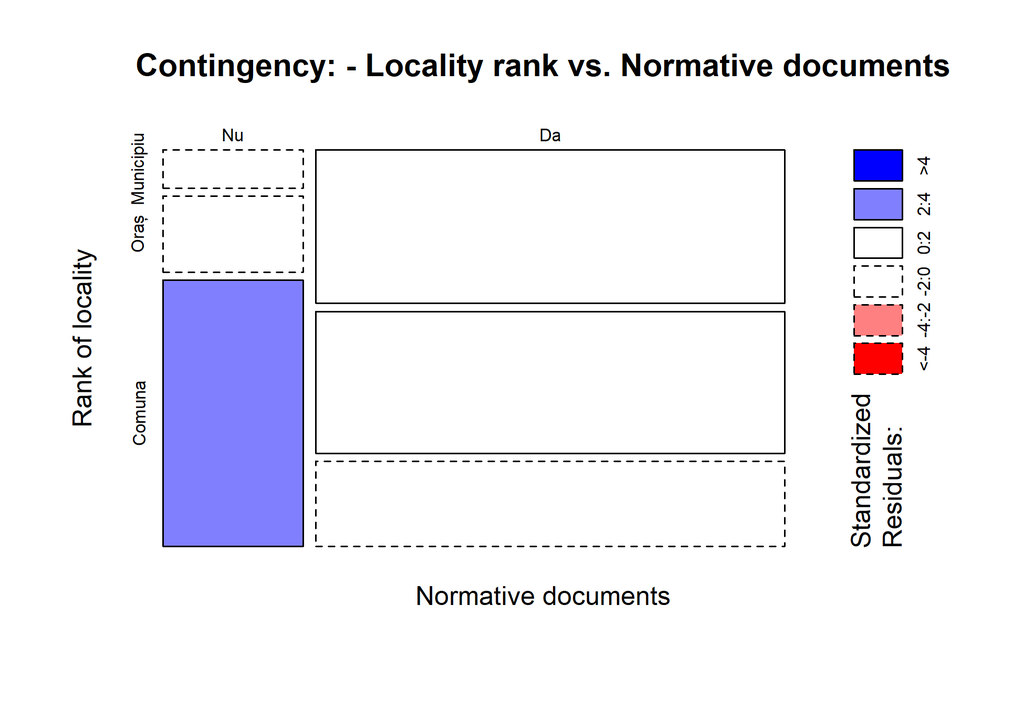

Contingency: - Locality rank vs. Normative documents

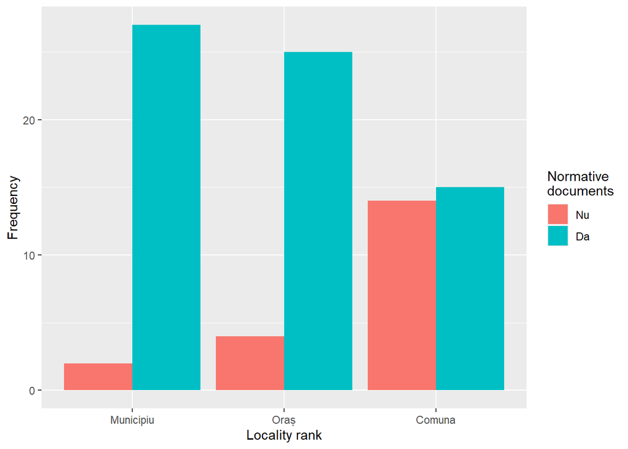

Barplot: - Locality rank vs. Normative documents

```r
  knitr::include_graphics("Article_files/figure-latex/Analysis-1.png")
```

## *a. Actele normative care reglementează organizarea și funcționarea autorității sau instituției publice*

În privința **actelor normative care reglementează organizarea și funcționarea autorității sau instituției publice** rezultă diferențe statistic semnificative ($\chi$<sup>2</sup>(2)=16.1, p=3.1886388^{-4}) determinate de rangul unității administrativ teritoriale. Într-adevăr, se pare că actele normative de acest tip nu există mai curând la nivelul **comunelor** (16.09% „Nu” față de 17.24% „Da”) în comparație cu orașele (4.6% „Nu” față de 28.74% „Da”) și municipiile (2.3% „Nu” față de 31.03% „Da”), doar între comune și celelalte două categorii de unități administrative existând diferențe statistic semnificative (vezi figurile @ref(fig:Moz-Range-I1) și @ref(fig:Bar-Range-I1)).

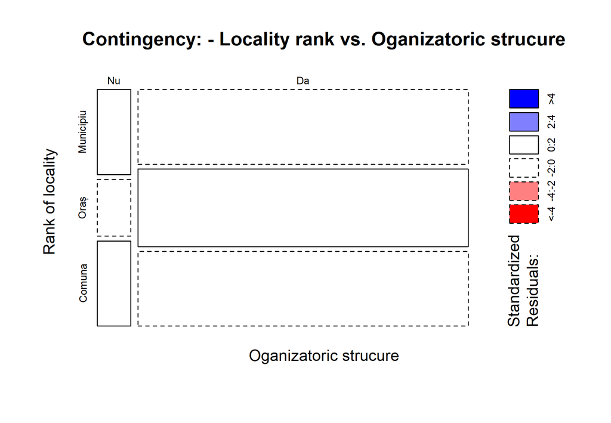

Contingency: - Locality rank vs. Organizatoric structure

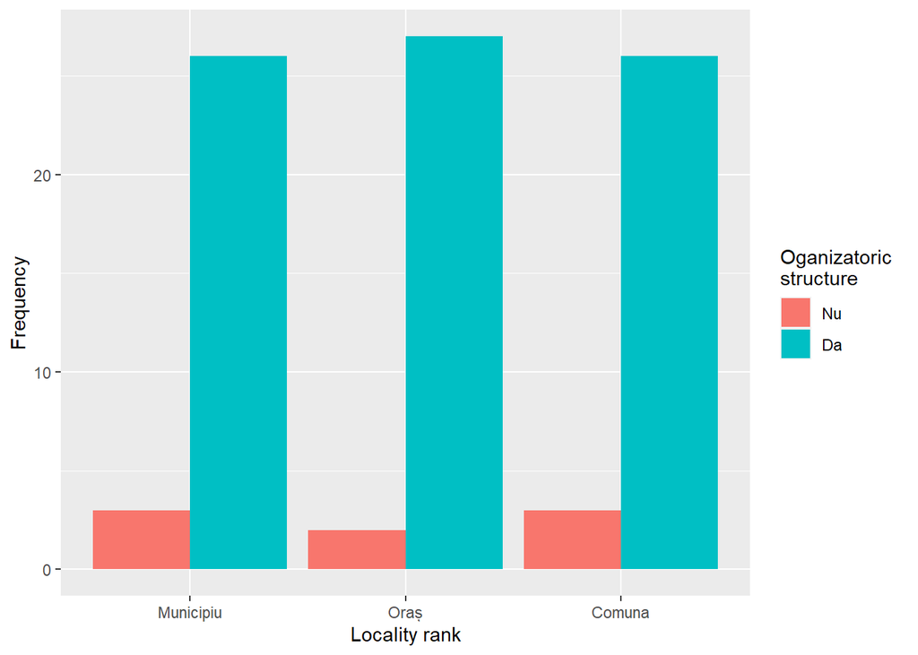

Barplot: - Locality rank vs. Organizatoric structure

```r
  knitr::include_graphics("Article_files/figure-latex/Analysis-2.png")
```

## *b. Structura organizatorică, atribuțiile departamentelor, programul de funcționare, programul de audiențe al autorității sau instituției publice*

Din punct de vedere al **structurii organizatorice, atribuțiilor departamentelor, programul de funcționare, programul de audiențe al autorității sau instituției publice** nu apar diferențe statistic semnificative ($\chi$<sup>2</sup>(2)=0.28, p=0.8713965) determinate de rangul unității administrativ teritoriale. La toate aceste unități predomină evaluările pozitive (Comune: 29.89%, Orașe: 31.03%, Municipii: 29.89%) în favoarea celor negative (Comune: 3.45%, Orașe: 2.3%, Municipii: 3.45%) (vezi figurile @ref(fig:Moz-Range-I2) și @ref(fig:Bar-Range-I2)).

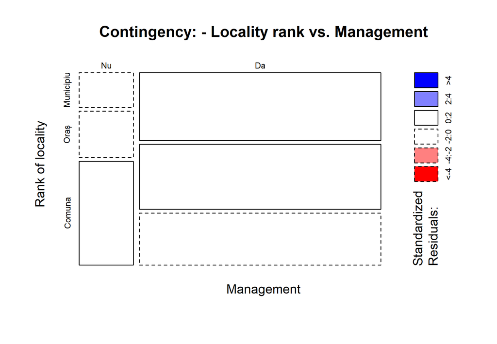

Contingency: - Locality rank vs. Contacts of the persons in charge

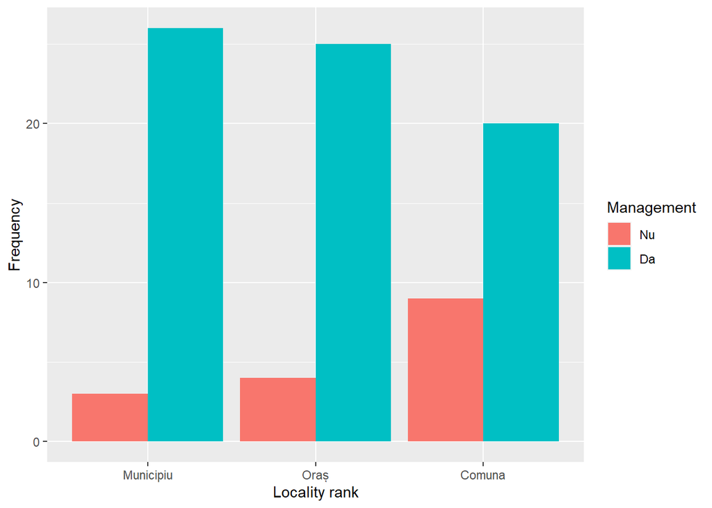

Barplot: - Locality rank vs. Contacts of the persons in charge

```r
  knitr::include_graphics("Article_files/figure-latex/Analysis-3.png")
```

## *c. Numele și prenumele persoanelor din conducerea autorității sau a instituției publice și ale funcționarului responsabil cu difuzarea informațiilor publice*

În ceea ce privește **numele persoanelor din conducerea autorității sau a instituției publice și ale funcționarului responsabil cu difuzarea informațiilor publice** nu apar diferențe statistic semnificative ($\chi$<sup>2</sup>(2)=4.75, p=0.0930964) determinate de rangul unității administrativ teritoriale. La toate aceste unități predomină evaluările pozitive (Comune: 22.99%, Orașe: 28.74%, Municipii: 29.89%) în favoarea celor negative (Comune: 10.34%, Orașe: 4.6%, Municipii: 3.45%) (vezi figurile @ref(fig:Moz-Range-I3) și @ref(fig:Bar-Range-I3)).

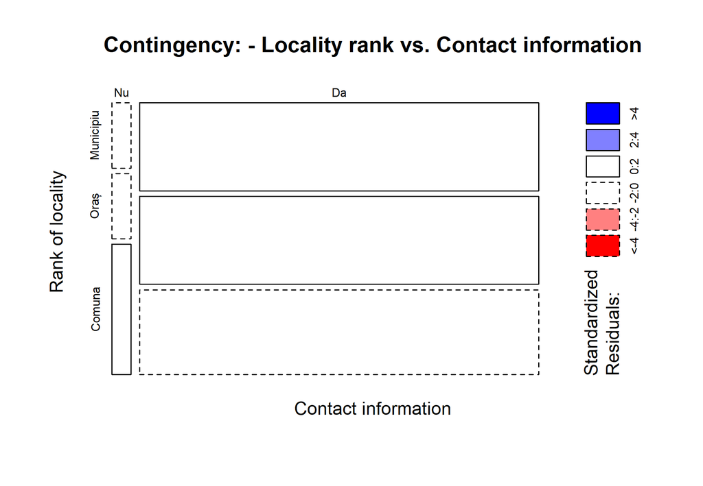

Contingency: - Locality rank vs. Contact details of the public authority

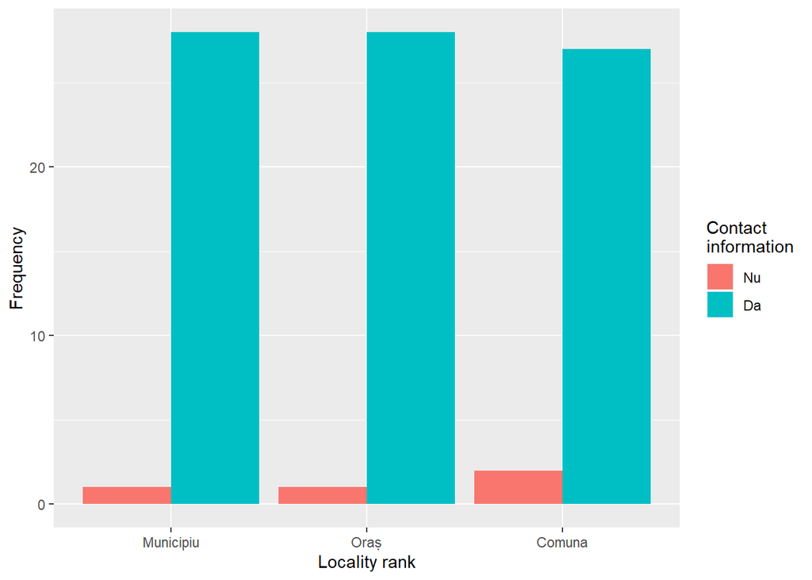

Barplot: - Locality rank vs. Contact details of the public authority

```r
  knitr::include_graphics("Article_files/figure-latex/Analysis-4.png")
```

## *d. Coordonatele de contact ale autorității sau instituției publice, respectiv: denumirea, sediul, numerele de telefon, fax, adresa de e-mail și adresa paginii de Internet*

În ceea ce privește **coordonatele de contact ale autorității sau instituției publice, respectiv: denumirea, sediul, numerele de telefon, fax, adresa de e-mail și adresa paginii de Internet** nu apar diferențe statistic semnificative ($\chi$<sup>2</sup>(2)=0.52, p=0.7694739) determinate de rangul unității administrativ teritoriale. La toate aceste unități predomină evaluările pozitive (Comune: 31.03%, Orașe: 32.18%, Municipii: 32.18%) în favoarea celor negative (Comune: 2.3%, Orașe: 1.15%, Municipii: 1.15%) (vezi figurile @ref(fig:Moz-Range-I4) și @ref(fig:Bar-Range-I4)).

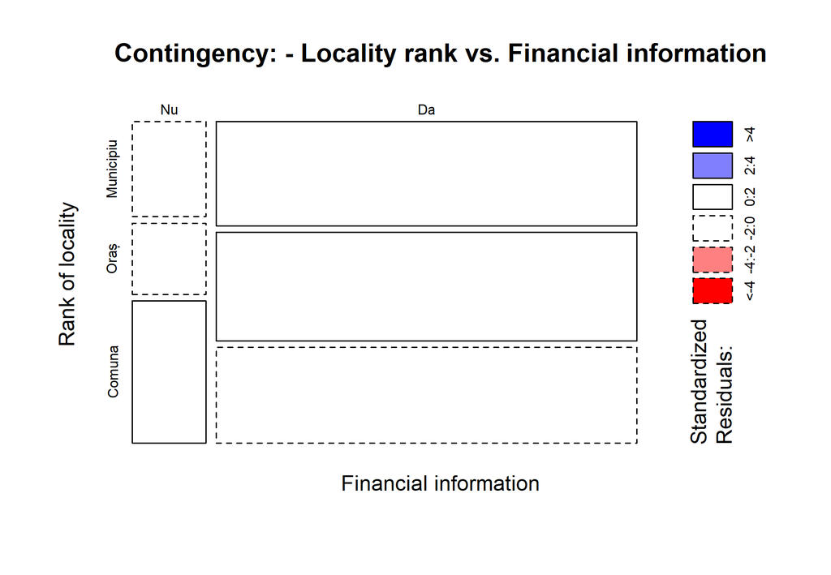

Contingency: - Locality rank vs. Financial sources, budget and balance sheet

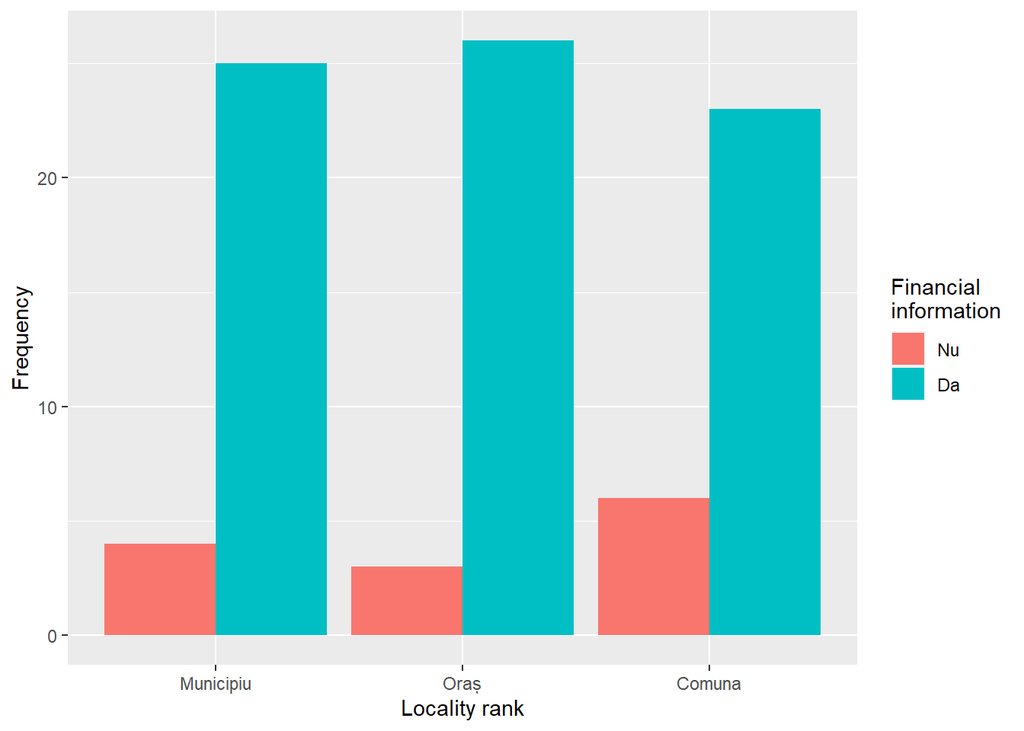

Barplot: - Locality rank vs. Financial sources, budget and balance sheet

```r
  knitr::include_graphics("Article_files/figure-latex/Analysis-5.png")
```

## *e. Sursele financiare, bugetul și bilanțul contabil*

În ceea ce privește **sursele financiare, bugetul și bilanțul contabil** nu apar diferențe statistic semnificative ($\chi$<sup>2</sup>(2)=1.27, p=0.5309666) determinate de rangul unității administrativ teritoriale. La toate aceste unități predomină evaluările pozitive (Comune: 26.44%, Orașe: 29.89%, Municipii: 28.74%) în favoarea celor negative (Comune: 6.9%, Orașe: 3.45%, Municipii: 4.6%) (vezi figurile @ref(fig:Moz-Range-I5) și @ref(fig:Bar-Range-I5)).

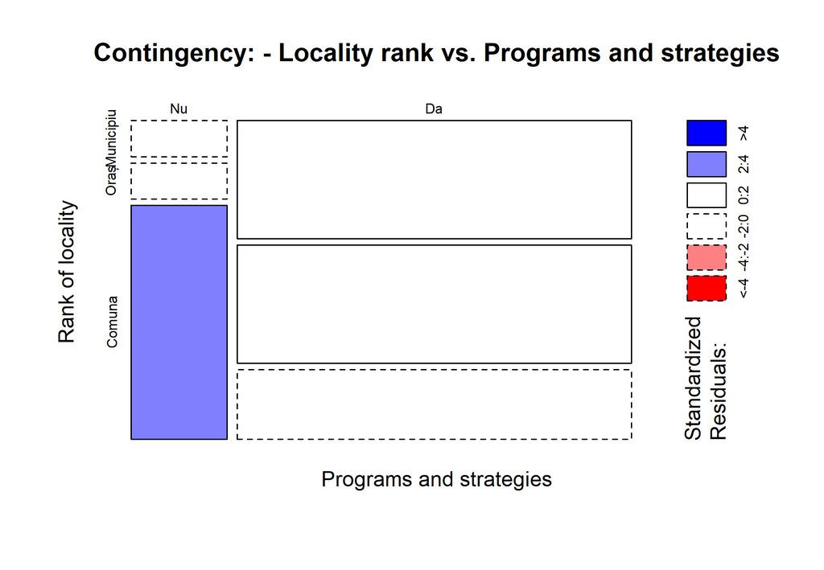

Contingency: - Locality rank vs. Own programs and strategies

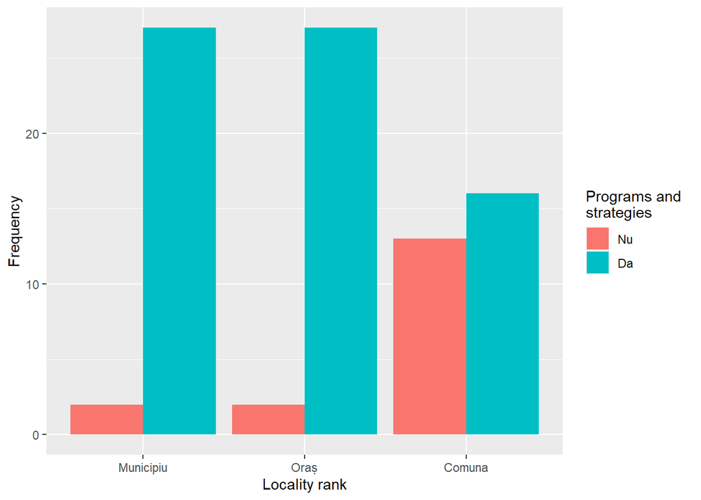

Barplot: - Locality rank vs. Own programs and strategies

```r
  knitr::include_graphics("Article_files/figure-latex/Analysis-6.png")
```

## *f. Programele și strategiile proprii*

În privința **programele și strategiile proprii** rezultă diferențe statistic semnificative ($\chi$<sup>2</sup>(2)=17.69, p=1.4392496^{-4}) determinate de rangul unității administrativ teritoriale. Într-adevăr, se pare că programele și strategiile proprii nu există mai curând la nivelul **comunelor** (14.94% „Nu” față de 18.39% „Da”) în comparație cu orașele (2.3% „Nu” față de 31.03% „Da”) și municipiile (2.3% „Nu” față de 31.03% „Da”), doar între comune și celelalte două categorii de unități administrative existând diferențe statistic semnificative (vezi figurile @ref(fig:Moz-Range-I6) și @ref(fig:Bar-Range-I6)).

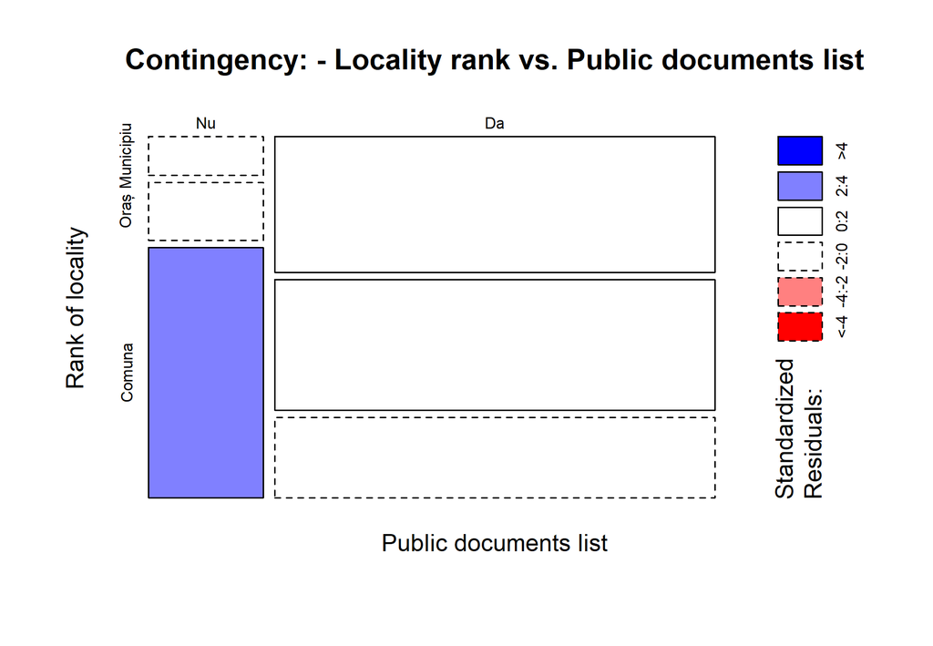

Contingency: - Locality rank vs. The list of documents of public interest

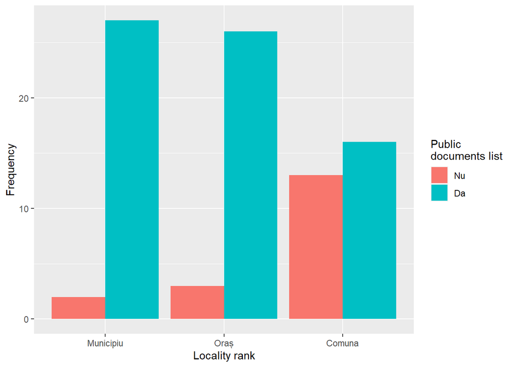

Barplot: - The list of documents of public interest

```r
  knitr::include_graphics("Article_files/figure-latex/Analysis-7.png")
```

## *g. Lista cuprinzând documentele de interes public*

În privința **lista cuprinzând documentele de interes public** rezultă diferențe statistic semnificative ($\chi$<sup>2</sup>(2)=15.55, p=4.1995528^{-4}) determinate de rangul unității administrativ teritoriale. Într-adevăr, se pare că lista documentelor de interes public nu există mai curând la nivelul **comunelor** (14.94% „Nu” față de 18.39% „Da”) în comparație cu orașele (3.45% „Nu” față de 29.89% „Da”) și municipiile (2.3% „Nu” față de 31.03% „Da”), doar între comune și celelalte două categorii de unități administrative existând diferențe statistic semnificative (vezi figurile @ref(fig:Moz-Range-I7) și @ref(fig:Bar-Range-I7)).

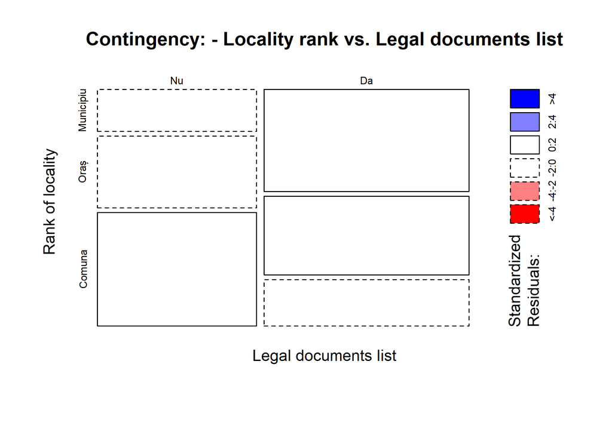

Contingency: - Locality rank vs. the list containing the categories of documents produced and / or managed, according to the law

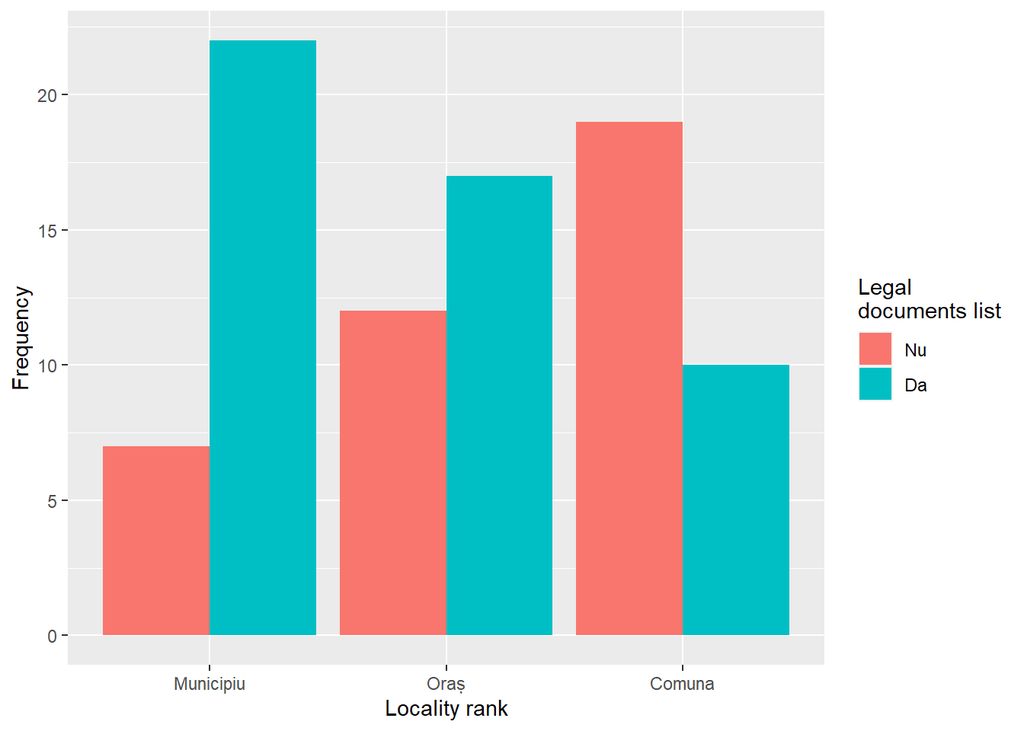

Barplot: - Locality rank vs. the list containing the categories of documents produced and / or managed, according to the law

```r
  knitr::include_graphics("Article_files/figure-latex/Analysis-8.png")
```

## *h. Lista cuprinzând categoriile de documente produse și/sau gestionate, potrivit legii*

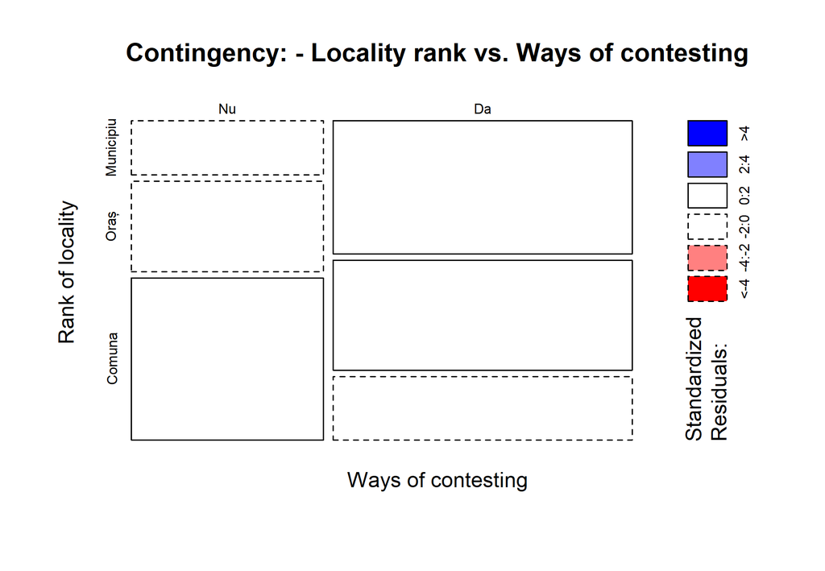

Contingency: - Locality rank vs. The modalities of contesting the decision

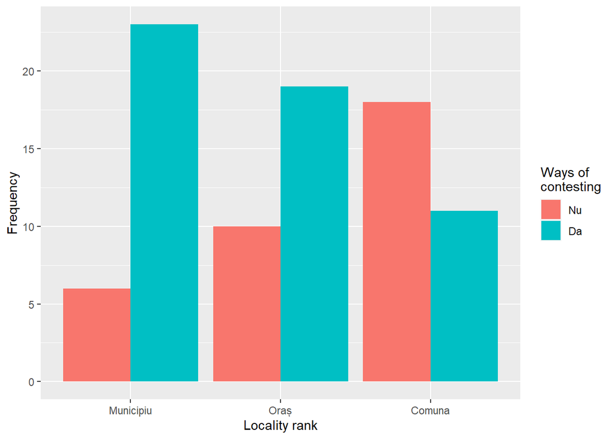

Barplot: - Locality rank vs. The modalities of contesting the decision

```r
  knitr::include_graphics("Article_files/figure-latex/Analysis-9.png")
```

## *i. Modalitățile de contestare a deciziei autorității sau a instituției publice în situația în care persoana se considera vătămată în privința dreptului de acces la informațiile de interes public solicitate*

În privința **modalitățile de contestare a deciziei autorității sau a instituției publice în situația în care persoana se considera vătămată în privința dreptului de acces la informațiile de interes public solicitate** rezultă diferențe statistic semnificative ($\chi$<sup>2</sup>(2)=10.81, p=0.0044836) determinate de rangul unității administrativ teritoriale. Într-adevăr, se pare că modalitatile de contestare a deciziei autorității sau a instituției publice nu există mai curând la nivelul **comunelor** (20.69% „Nu” față de 12.64% „Da”) în comparație cu orașele (11.49% „Nu” față de 21.84% „Da”) și municipiile (6.9% „Nu” față de 26.44% „Da”), doar între comune și celelalte două categorii de unități administrative existând diferențe statistic semnificative (vezi figurile @ref(fig:Moz-Range-I9) și @ref(fig:Bar-Range-I9)).

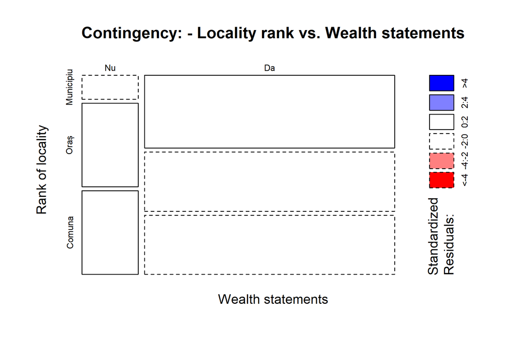

Contingency: - Locality rank vs. Wealth and interest statements

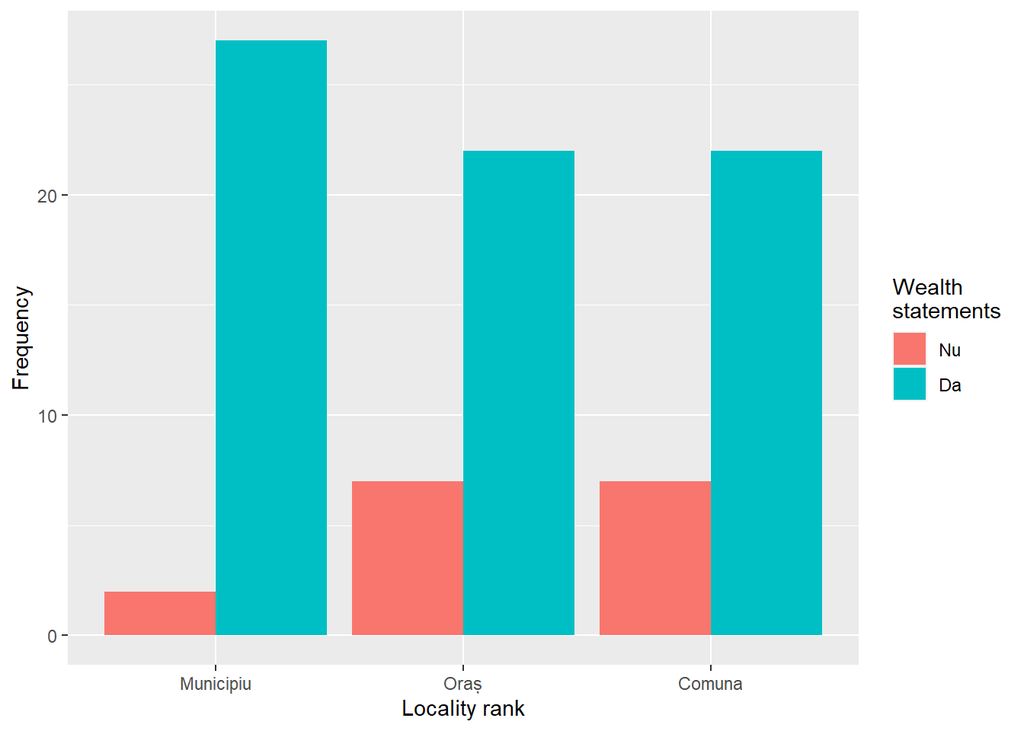

Barplot: - Locality rank vs. Wealth and interest statements

```r
  knitr::include_graphics("Article_files/figure-latex/Analysis-10.png")
```

## *j. Declarații de avere și interese*

În ceea ce privește **Declarații de avere și interese** nu apar diferențe statistic semnificative ($\chi$<sup>2</sup>(2)=3.83, p=0.1473989) determinate de rangul unității administrativ teritoriale. La toate aceste unități predomină evaluările pozitive (Comune: 25.29%, Orașe: 25.29%, Municipii: 31.03%) în favoarea celor negative (Comune: 8.05%, Orașe: 8.05%, Municipii: 2.3%) (vezi figurile @ref(fig:Moz-Range-I10) și @ref(fig:Bar-Range-I10)).

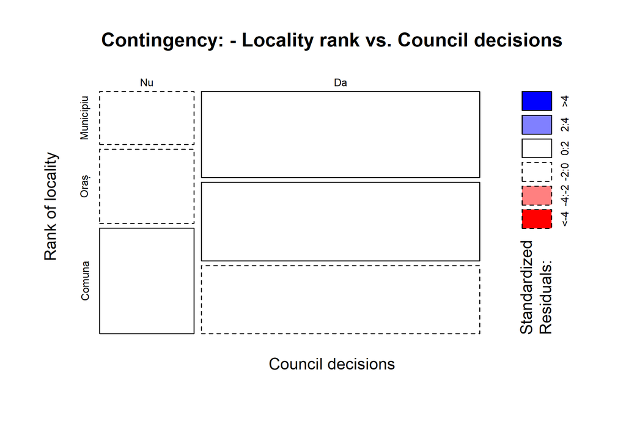

Contingency: - Locality rank vs. Council decisions

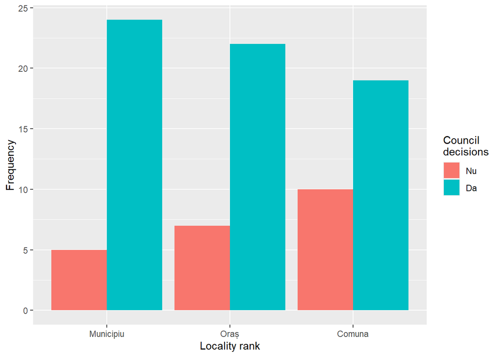

Barplot: - Locality rank vs. Council decisions

```r
  knitr::include_graphics("Article_files/figure-latex/Analysis-11.png")
```

## *k. Hotărâri de Consiliu*

În ceea ce privește **Hotărâri de Consiliu** nu apar diferențe statistic semnificative ($\chi$<sup>2</sup>(2)=2.31, p=0.3147602) determinate de rangul unității administrativ teritoriale. La toate aceste unități predomină evaluările pozitive (Comune: 21.84%, Orașe: 25.29%, Municipii: 27.59%) în favoarea celor negative (Comune: 11.49%, Orașe: 8.05%, Municipii: 5.75%) (vezi figurile @ref(fig:Moz-Range-I11) și @ref(fig:Bar-Range-I11)).

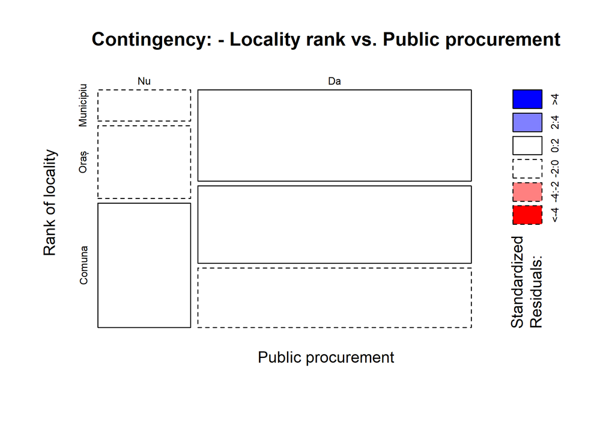

Contingency: - Locality rank vs. Public procurement contracts

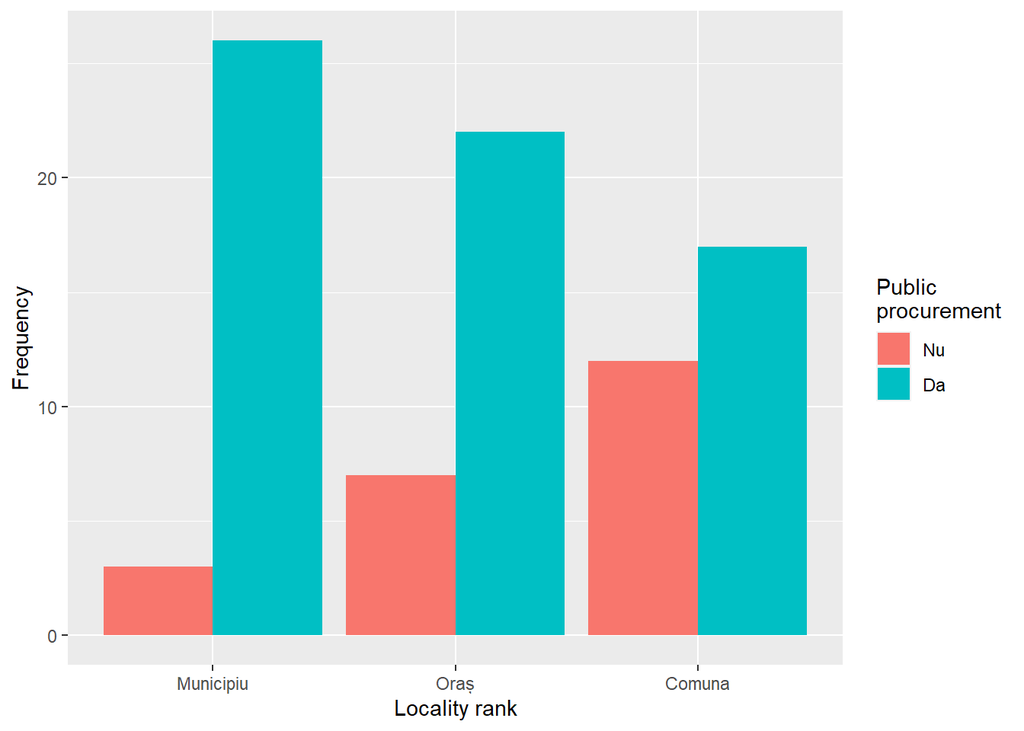

Barplot: - Locality rank vs. Public procurement contracts

```r
  knitr::include_graphics("Article_files/figure-latex/Analysis-12.png")
```

## *l. Contracte de achiziții publice*

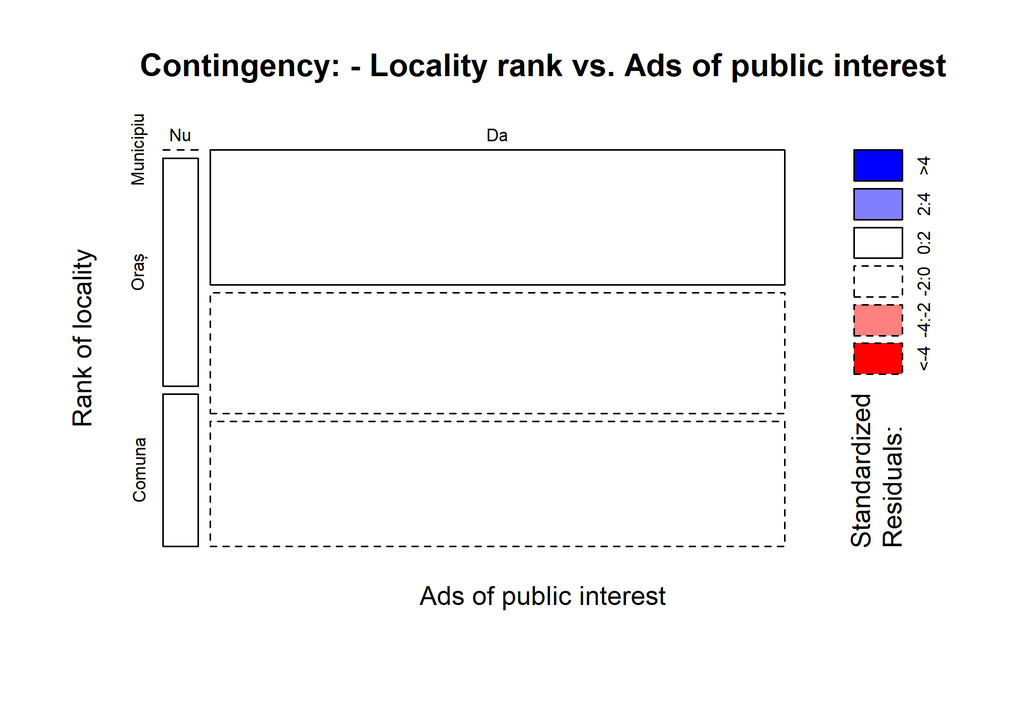

Contingency: - Locality rank vs. Ads of public interest

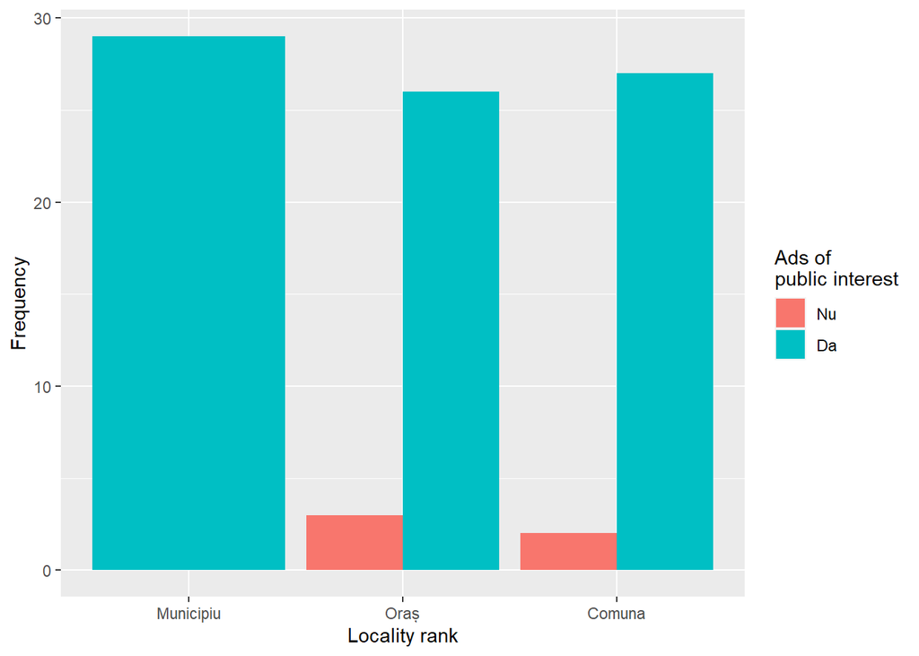

Barplot: - Locality rank vs. Ads of public interest

```r
  knitr::include_graphics("Article_files/figure-latex/Analysis-13.png")
```

## *m. Anunțuri de interes public*

În ceea ce privește **Anunțuri de interes public** nu apar diferențe statistic semnificative ($\chi$<sup>2</sup>(2)=2.97, p=0.2264195) determinate de rangul unității administrativ teritoriale. La toate aceste unități predomină evaluările pozitive (Comune: 31.03%, Orașe: 29.89%, Municipii: 33.33%) în favoarea celor negative (Comune: 2.3%, Orașe: 3.45%, Municipii: 0%) (vezi figurile @ref(fig:Moz-Range-I13) și @ref(fig:Bar-Range-I13)).

# Discussion

# References

Aust, Frederik, and Marius Barth. 2020. *papaja: Prepare Reproducible APA Journal Articles with R Markdown*. https://github.com/crsh/papaja.

Barth, Marius. 2022. *tinylabels: Lightweight Variable Labels*. https://cran.r-project.org/package=tinylabels.

Chen, Yu-Che, and Teng-Wen Chang. 2019. “Explaining Government’s Online Transparency on Collaborative Policy Platforms: Risk Management and Configurational Conditions.” *Public Performance & Management Review*, March, 1–27. https://doi.org/10.1080/15309576.2019.1574591.

R Core Team. 2022. *R: A Language and Environment for Statistical Computing*. Vienna, Austria: R Foundation for Statistical Computing. https://www.R-project.org/.

Radu, Bianca. 2019. “The Impact of Transparency on the Citizen Participation in Decision- Making at the Municipal Level in Romania.” *Central European Public Administration Review* 17 (1): 111–30. https://doi.org/10.17573/cepar.2019.1.06.

Xie, Yihui. 2015. *Dynamic Documents with R and Knitr*. 2nd ed. Boca Raton, Florida: Chapman; Hall/CRC. https://yihui.org/knitr/.

Zhu, Hao. 2021. *kableExtra: Construct Complex Table with ’Kable’ and Pipe Syntax*. https://CRAN.R-project.org/package=kableExtra.